# CA 22: Linear Regression

```r
penguins <- na.omit(penguins)
```

## Linear Regression

```r
load("~/MAT104-Fall2024/Week12/parenthood.Rdata")
```

Let’s go back to the parenthood data we used last class:

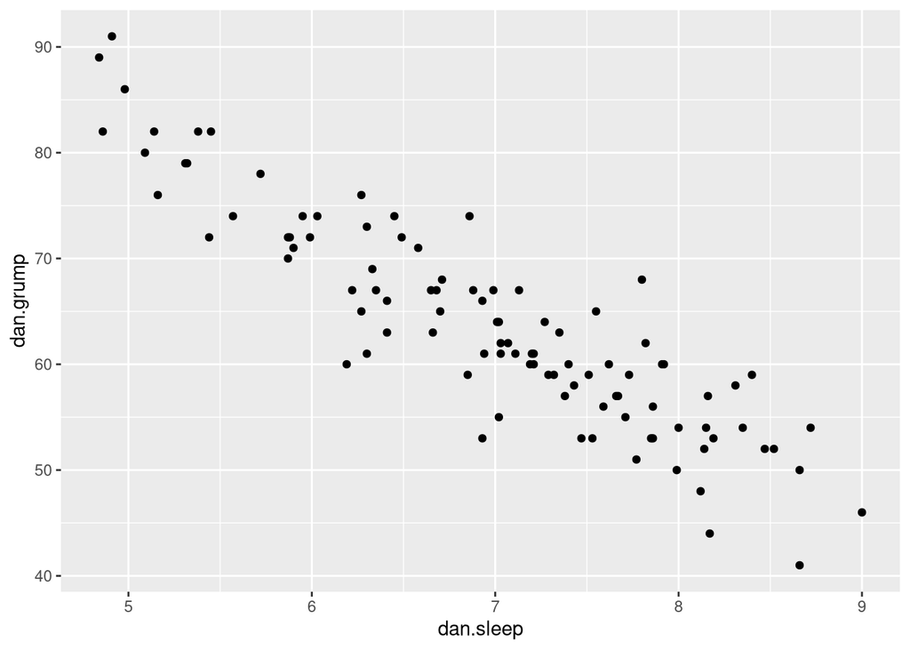

```r
ggplot(parenthood, aes(x=dan.sleep,y=dan.grump))+geom_point()
```

The data looks like there is a linear relationship between `dan.sleep` and `dan.grump`, so let’s add a line to our plot that represents this relationship.

### Meaning of the Parameters

To make an equation for a line we use the slope-intercept formula:

$$y=mx+b$$
where $m$ is the slope of the line and $b$ is the $y$-intercept.

In statistics, we typically use different letters but the equation is the same:
$$\hat{Y_i} = b_1 X_i + b_0$$
where $b_1$ is the slope and $b_0$ is the $y$-intercept. The values $b_1$ and $b_0$ are called coefficients.

1. Interpret $b_1$, $b_0$, $X_i$, and $\hat{Y}_i$ in the context of the parenthood data. Make a best guess for $b_0$ and $b_1$. (We guessed $b_0 = 135$ and $b_1 = -10$ last class already but have not yet interpreted their meanings).

$b_1=-10$ for every additional hour of sleep Danielle is 10 units less grumpy or (has 10 less grumps)

$b_0 = 135$ when Danielle stays up all night she has 135 grumps

$X_i$ number of hours Danielle slept on the i-th day

$\hat{Y}_i$ is how grumpy we predict Danielle will be on the i-th day

Let’s add the line we predicted to the graph

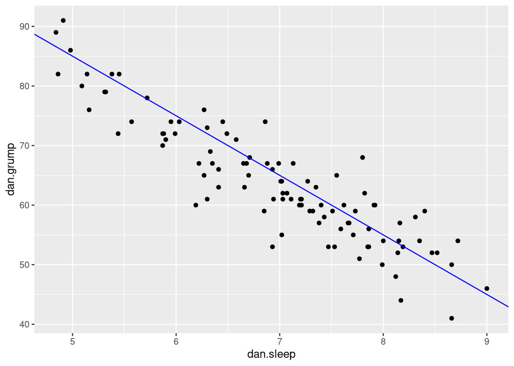

```r
ggplot(parenthood, aes(x=dan.sleep,y=dan.grump)) +
  geom_point() +
  geom_abline(intercept = 135, slope = -10, color="blue")
```

### Residuals

- We can do better than estimating by eye though.
- We should choose the line that minimize the error in our predictions.

The graph below displays the error between our prediction and the true data in red:

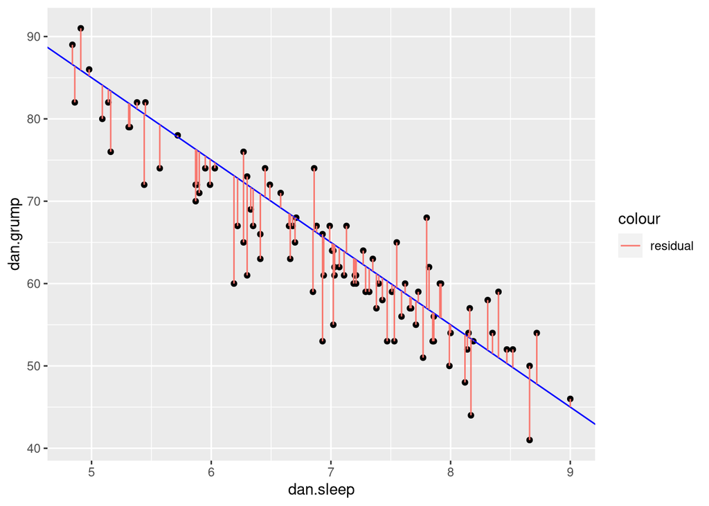

```r
# Use our slope and intercept guesses to predict the y-values
predictions <- data.frame(Y_hat = -10*(parenthood$dan.sleep) + 135)

# Plot segments joining the actual points and the predicted points
ggplot(parenthood, aes(x=dan.sleep,y=dan.grump)) +
  geom_point() +
  geom_abline(intercept = 135, slope = -10, color="blue") +
  geom_segment(aes(xend = dan.sleep, yend = predictions$Y_hat, color = "residual"))
```

To lengths of these little red segments are called **residuals**. We can find how big the residuals are by finding the difference between the predicted value and the actual value:

$$\epsilon_i = Y_i - \hat{Y}_i$$

2. Calculate the residual corresponding to the first day, $\epsilon_1$.

```r
56 - 59.1
```

```
## [1] -3.1
```

- the residual is negative when our prediction is an overestimate
- the residual is positive when our prediction is an underestimate.

Putting these ideas together, we can see that our real data is equal to our prediction plus the residuals:

$$Y_i = \hat{Y}_i + \epsilon_i = b_1X_i + b_0 + \epsilon_i$$

## Minimizing error

- the residuals describe the error in the predictions our model makes
- we want to choose the model that minimizes the residuals
- One approach for this is to minimize the so called **sum of the squared residuals**:

$$\sum \epsilon_i^2 = \sum (Y_i - \hat{Y}_i)^2$$

```r
#find the sum of the squared residuals
sum((parenthood$dan.grump - predictions$Y_hat)^2)
```

```
## [1] 2222.52
```

```r
# 2222.52
```

### Using R to find the fits

```r
# the R function to find the best linear model is lm()
lm(parenthood$dan.grump ~ parenthood$dan.sleep)
```

```
##
## Call:
## lm(formula = parenthood$dan.grump ~ parenthood$dan.sleep)
##
## Coefficients:
##          (Intercept)  parenthood$dan.sleep
##              125.956                -8.937
```

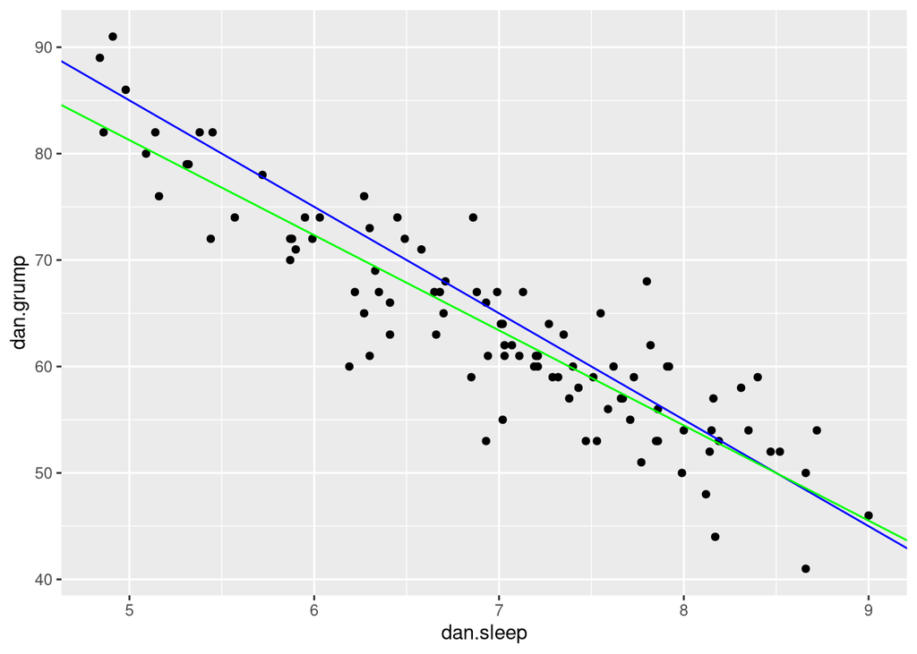

```r
ggplot(parenthood, aes(x=dan.sleep,y=dan.grump)) +
  geom_point() +
  geom_abline(intercept = 135, slope = -10, color="blue") +
  geom_abline(intercept = 125.956, slope = -8.937, color="green")
```

```r
# new sum of the square residuals
predictions2 <- data.frame(Y_hat = -8.937*(parenthood$dan.sleep)+ 125.956)
sum((parenthood$dan.grump - predictions2$Y_hat)^2)
```

```
## [1] 1838.714
```

```r
# this is much smaller than 2222, so this is a better model. IN fact, this is the best we can possibly do with a straight line.
```

## Multiple Regression

The model we use for two predictors is:
$$\hat{Y}_i = b_2 X_{i,2} + b_1 X_{i,1} + b_0$$

where $X_{i,2}$ is the amount of sleep the baby got on day $i$ and $X_{i,1}$ is the amount of sleep Danielle got on day $i$.

- If we had three predictors the equation would be:
  $$\hat{Y}_i = b_3 X_{i,3} + b_2 X_{i,2} + b_1 X_{i,1} + b_0$$

To find the best fitting regression line we use `lm()`:

```r
lm(parenthood$dan.grump ~ parenthood$dan.sleep + parenthood$baby.sleep)
```

```
##
## Call:
## lm(formula = parenthood$dan.grump ~ parenthood$dan.sleep + parenthood$baby.sleep)
##
## Coefficients:
##           (Intercept)   parenthood$dan.sleep  parenthood$baby.sleep
##             125.96557               -8.95025                0.01052
```

```r
# the linear model associated to this would be
# Y_hat = -8.95*X_1 + 0.0105 * X_2 + 125.96557
```

```r
scatter3d(dan.grump ~ dan.sleep + baby.sleep, parenthood)
rglwidget()
```

[interactive chart not shown]

3. Find the residual corresponding to the first day using this new model with two predictors.

## Class Activity

4. Using the penguins data set, perform a simple linear regression to model body mass using the predictor variable bill length. What values do you get for $\hat{b}_0$ and $\hat{b}_1$? Graph a scatter plot for the data and include your regression model in the plot.

5. Find the sum of the square residuals for the model in exercise 1.
6. Use `cor()` to find the strength of the correlation between bill length and body mass.
7. Use simple linear regression to model the relationship between flipper length and body mass for the penguin data. What values do you get for $\hat{b}_0$ and $\hat{b}_1$? Plot a scatter plot for the data with the line you found.
8. Use multiple linear regression to model the body mass using the predictors flipper length and bill length for the penguin data. Assuming $X_1$ is flipper length and $X_2$ is bill length, what values do you get for $\hat{b}_0$, $\hat{b}_1$, and $\hat{b}_2$?